# Modeling PHQ-9 Scores in Chilean Longitudinal Social Survey

13-11-2021

## About my research

- **Broad Interest**: Asses which groups of people have the more severe and persistent depressive symptoms (as measured by PHQ-9).
- **Research goal**: To model the longitudinal variations of PHQ-9 scores among ELSOC participants.
- **Metodology**: Generalized linear mixed effects models.
- **Current state**: Exploring probability distributions for the first year of the study.
- **Today’s Presentation**: A discrete data probability model that take into account the excess of zeros (ZINB regression).

## About the data

- [ELSOC-COES](https://coes.cl/encuesta-panel/) Chilean Longitudinal Social Survey. 5 year panel data of adults since 2016. Aims to be representative of urban chilean population.
- More than 300 variables from different modules: *“Territory”*, *“Social attitudes and networks”*, *“Citizenship and Democracy”*,*“Inequality and Legitimacy”*, *“Social Conflict”*, *“Health and Wellbeing”*, *“Sociodemographic”*.
- **Health and Wellbeing**: Life satisfaction, PHQ-9, Stressors, recient health issues, substances use, support networks, acces to health systems, BMI.
- You have PHQ-9 scores for the same group of adults each wave of the study, with hundreds of variables to play with.

## PHQ-9 Scores in ELSOC respondents (First wave)

## PHQ-9 Items (1-3)

Over the last 2 weeks, how often have you been bothered by any of the following problems?

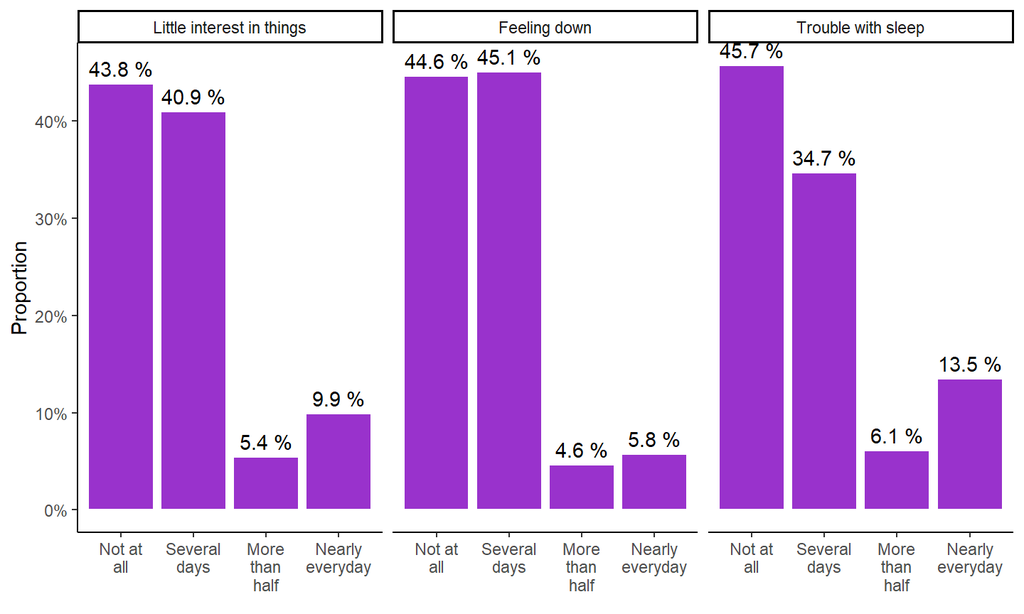

## PHQ-9 Items (4-6)

Over the last 2 weeks, how often have you been bothered by any of the following problems?

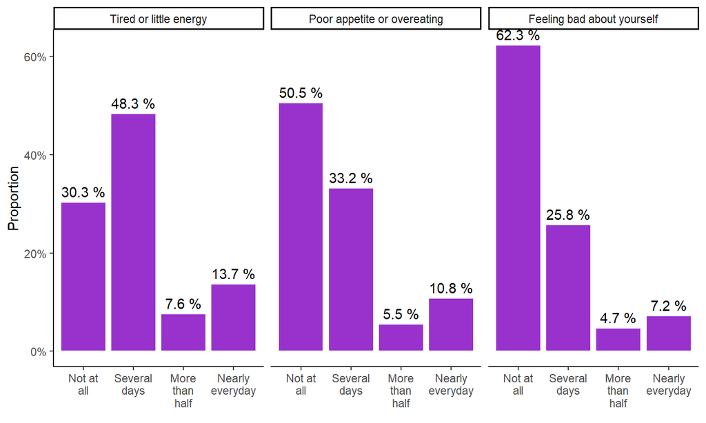

## PHQ-9 Items (7-9)

Over the last 2 weeks, how often have you been bothered by any of the following problems?

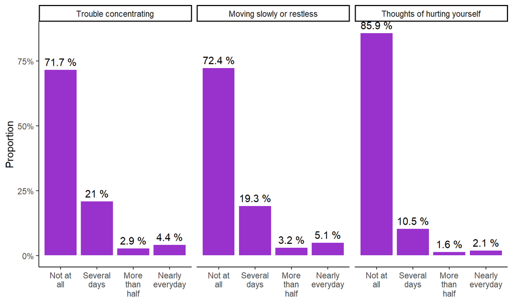

## Aggregated PHQ-9 score

For each of the 9 items recode “Not at all” as 0, “Several days” as 1, “More than half the days” as 2, and “Nearly everyday” as 3. Then sum all items. The result is a score that ranges from 0 to 27.

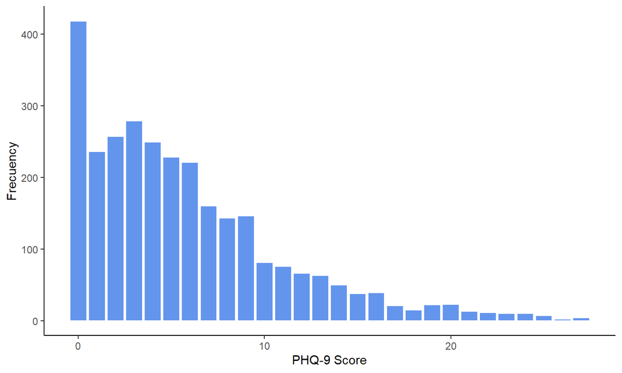

## Differences in depressive symptoms (1)

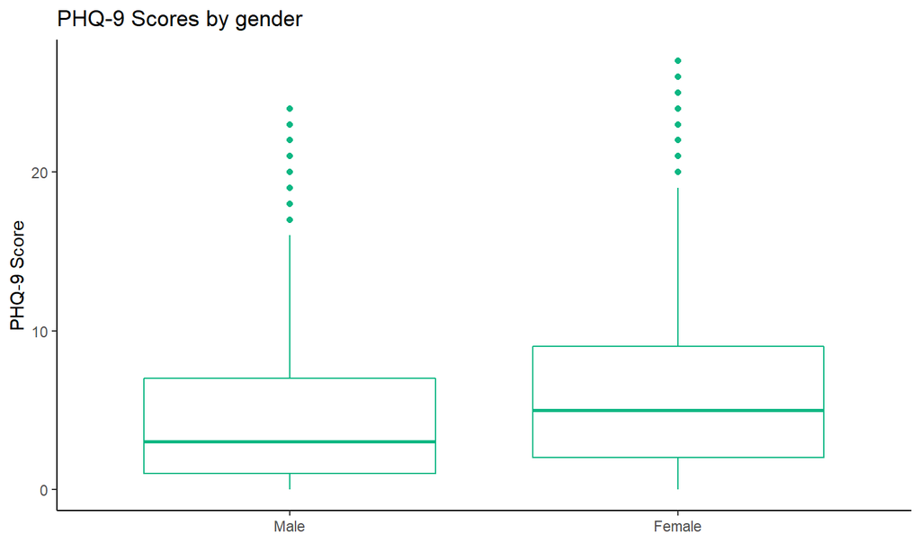

## Differences in depressive symptoms (2)

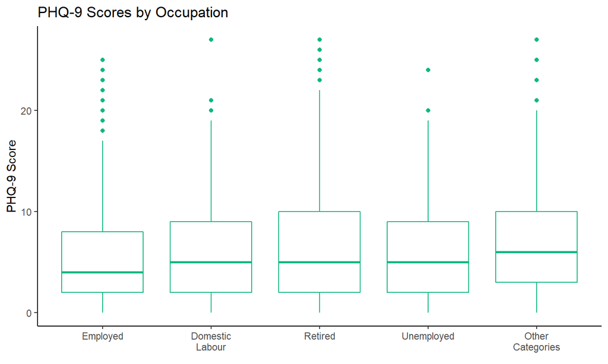

## Differences in depressive symptoms (3)

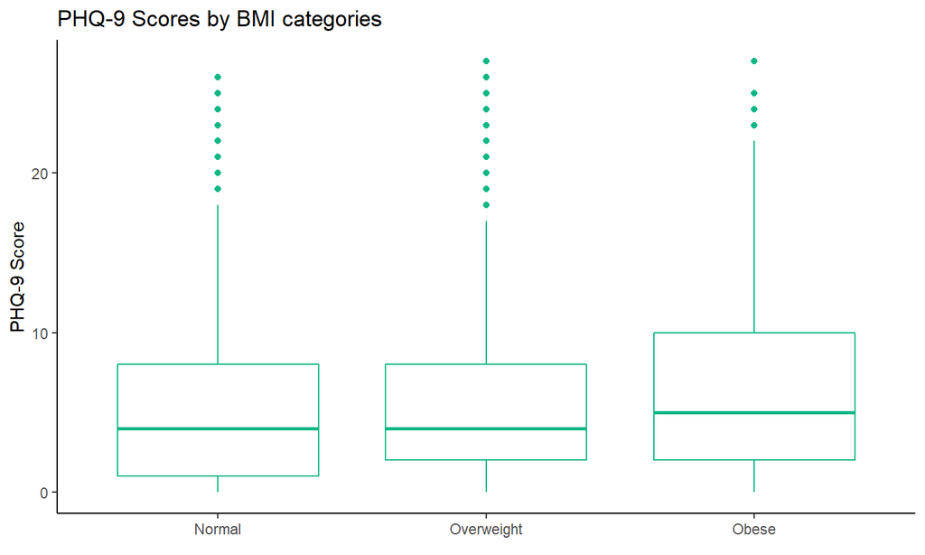

## Differences in depressive symptoms (4)

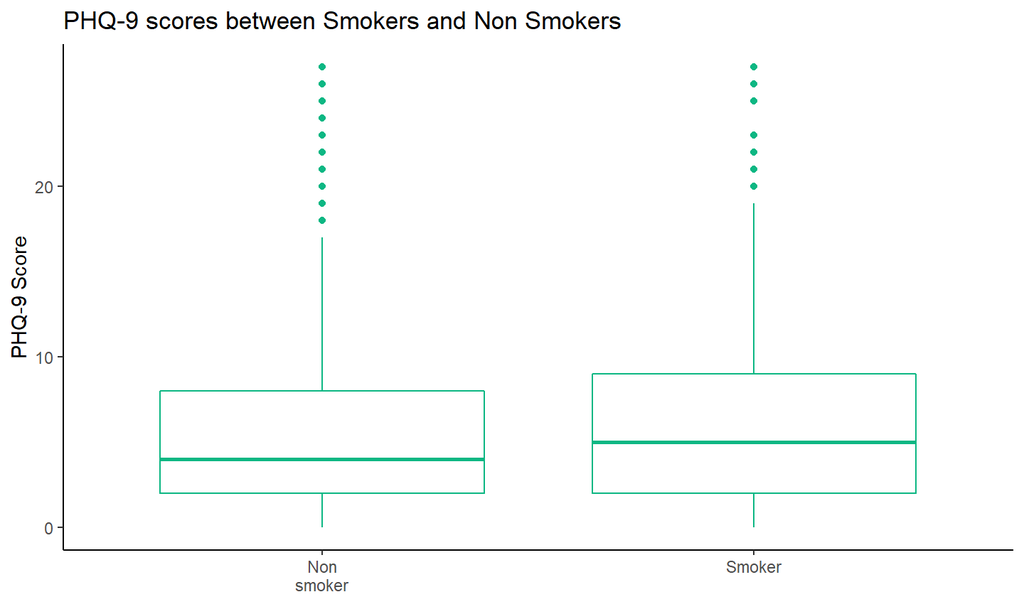

## Differences in depressive symptoms (5)

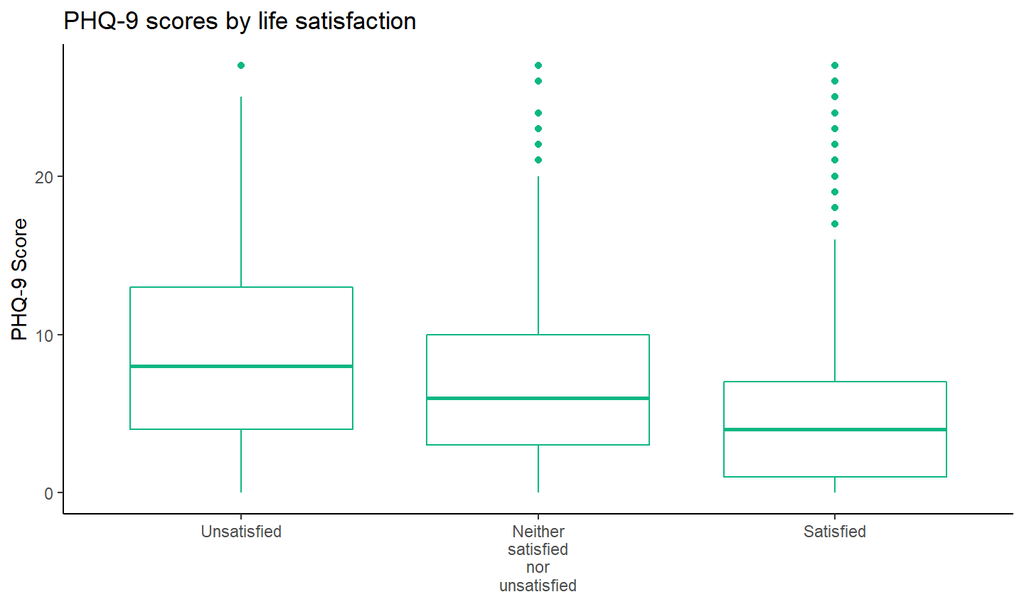

## How can we model discrete over-disperse data?

## Modeling approaches for discrete over-disperse data

- Against the normal model
- The Poisson Model
- Over disperse data (Negative Binomial)
- Excess of ceros (Zero-Inflated)

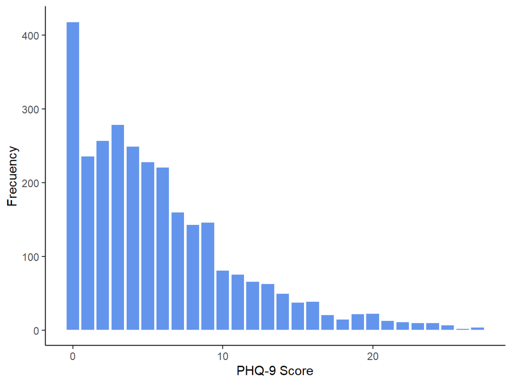

## Zero-Inflated Negative Binomial Regression

## ZINB Regression

- You model two separate processes:

- ```
  PHQ-9 score > 1
  ```

- ```
  Having a 0 PHQ-9 score
  ```

## Toy example ZINB Regression

- **Gender**: Categorical: *“Male”*, *“Female”*.
- **Stressors**: Number of vital events in the last year (death of family member, illnes, Job layoff, etc). Numeric 0-8.
- **Age**: Numeric 18-88.
- **Smoker**: Categorical: *“Non Smoker”*, *“Smoker”*.
- **Body Mass Index (BMI)**: Continuous, median value 26,83.
- **Life Satisfaction**: Categorical: *“Not Satisfied”* (Negative),*“Neither satisfied nor dissatisfied”* (Neutral), *“Satisfied”* (Positive).

## Modeling PHQ-9 Scores by ZINB regression

Statistical models

|  | Zero-Inflated Negative Binomial Regression |
| --- | --- |
| Count: Intercept | 1.50 (0.11)*** |
| Count: BMI | 0.01 (0.00)*** |
| Count: Female | 0.26 (0.03)*** |
| Count: Stressors | 0.14 (0.02)*** |
| Count: Age | 0.00 (0.00) |
| Count: Neutral Satisfaction | -0.18 (0.06)** |
| Count: Positive Satisfaction | -0.48 (0.05)*** |
| Count: Smoker | 0.05 (0.04) |
| Count: Over dispersion parameter | 0.93 (0.05)*** |
| Zero: Intercept | -1.88 (0.73)* |
| Zero: BMI | -0.04 (0.02) |
| Zero: Female | -0.56 (0.17)** |
| Zero: Stressors | -0.51 (0.12)*** |
| Zero: Age | 0.01 (0.01)* |
| Zero: Neutral Satisfaction | 0.40 (0.45) |
| Zero: Positive Satisfaction | 0.86 (0.37)* |
| Zero: Smoker | -0.29 (0.20) |
| AIC | 14113.18 |
| Log Likelihood | -7039.59 |
| Num. obs. | 2585 |

p < 0.001; p < 0.01; p < 0.05

## Coefficients Interpretation

| Variable | Count | Zero |
| --- | --- | --- |
| Intercept | 4.4848 | 0.1533 |
| BMI | 1.0132 | 0.9652 |
| Female | 1.2980 | 0.5697 |
| Stressors | 1.1481 | 0.6024 |
| Age | 1.0002 | 1.0137 |
| Neutral Satisfaction | 0.8389 | 1.4934 |
| Positive Satisfaction | 0.6190 | 2.3688 |
| Smoker | 1.0552 | 0.7518 |

## Count Effects in PHQ-9 Scores

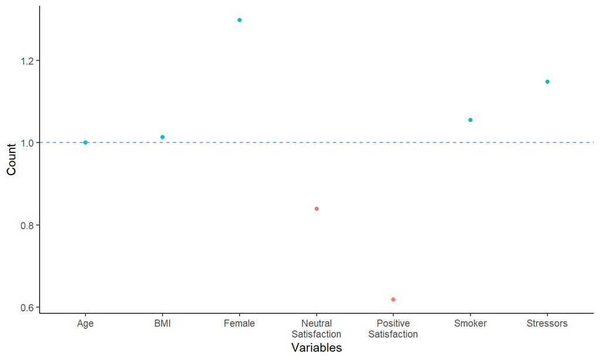

## Zero effects in PHQ-9 Scores

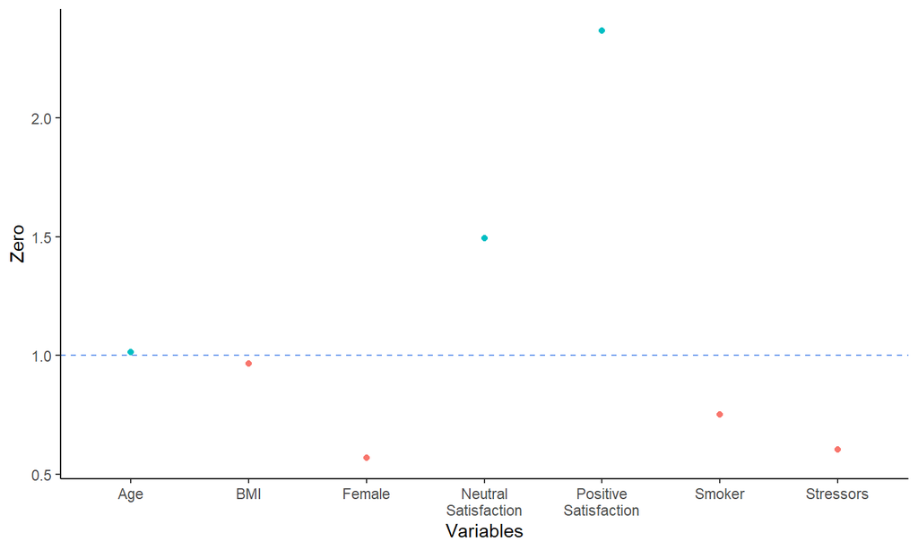

## What does that mean? Count part

- A unit increase in **BMI** increases the mean PHQ-9 score by a factor of 1%.
- **Female** respondents have an increase of their PHQ-9 scores by a factor of 29%.
- Each **stresor** event that happens to the respondant it’s related with an increase their predicted PHQ-9 scores by a factor of 14%.
- **Age** and being an **Smoker** are not statistical significant for predicting phq-9 scores above 1.

## Predicting PHQ-9 by ZINBR

## Predicting PHQ-9 Scores

Let’s think about two people:

- **Person 1**: 45 years old, male. 0 stressors events in the last year. Satisfied with life. Non smoker.And with “Healthy Weight” (BMI=22).
- **Person 2**: 27 years old, female. 1 stressor event in the last year. Unsatisfied with life. Smoker. Moderate Obesity (BMI= 30).

## Predicting PHQ-9 Scores by ZINB Regression

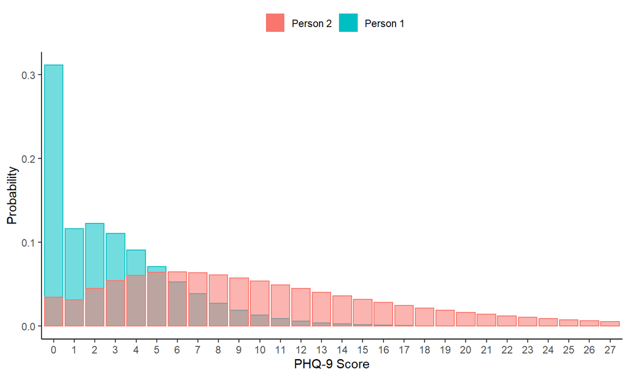

## Future directions

- Assesing model fit for different probability distributions.
- Adding the longitudinal aspect of the model.
- Variable selection.
- Controlling missing data, adding sample weights, control panel attrition.

## I’m happy to hear about

- Applications of PHQ-9 in longitudinal settings.
- Relevant factors in severity and persistance of depressive symptoms.